# Regression Model for [Project Name] Using R version 04.0

## 3. Prepare Data

Some dataset may require additional preparation activities that will best exposes the structure of the problem and the relationships between the input attributes and the output variable. Some data-prep tasks might include:

- Cleaning data by removing duplicates, marking missing values and even imputing missing values.
- Feature selection where redundant features may be removed.
- Data transforms where attributes are scaled or redistributed in order to best expose the structure of the problem later to learning algorithms.

### 3.a) Data Cleaning

```r
# Not applicable for this iteration of the project.

# Mark missing values
#invalid <- 0
#entireDataset$some_col[entireDataset$some_col==invalid] <- NA

# Impute missing values
#entireDataset$some_col <- with(entireDataset, impute(some_col, mean))
```

### 3.b) Feature Selection

```r
# Not applicable for this iteration of the project.
```

### 3.c) Data Transforms

```r
# Not applicable for this iteration of the project.
```

### 3.d) Split-out training and validation datasets

We create a training dataset (variable name “training”) and a validation dataset (variable name “validation”).

```r
set.seed(seedNum)

# Create a list of the rows in the original dataset we can use for training
training_index <- createDataPartition(entireDataset$targetVar, p=0.70, list=FALSE)
# Use 70% of data to training and testing the models
training <- entireDataset[training_index,]
# Select the remaining 30% of the data for validation
validation <- entireDataset[-training_index,]

dim(training)
```

```
## [1] 356  14
```

```r
dim(validation)
```

```
## [1] 150  14
```

```r
proc.time()-startTimeScript
```

```
##    user  system elapsed
##    3.50    1.23    4.89
```

## 4. Model and Evaluate Algorithms

After the data-prep, we next work on finding a workable model by evaluating a subset of machine learning algorithms that are good at exploiting the structure of the dataset. The typical evaluation tasks include:

- Defining test options such as cross validation and the evaluation metric to use.
- Spot checking a suite of linear and nonlinear machine learning algorithms.
- Comparing the estimated accuracy of algorithms.

For this project, we will evaluate one linear, three non-linear, and three ensemble algorithms:

Linear Algorithm: Linear Regression

Non-Linear Algorithms: Decision Trees (CART), k-Nearest Neighbors, and Support Vector Machine

Ensemble Algorithms: Bagged CART, Random Forest, and Stochastic Gradient Boosting

The random number seed is reset before each run to ensure that the evaluation of each algorithm is performed using the same data splits. It ensures the results are directly comparable.

### 4.a) Set test options and evaluation metric

```r
# Run algorithms using 10-fold cross validation
control <- trainControl(method="repeatedcv", number=10, repeats=3)
metricTarget <- "RMSE"
```

### 4.b) Generate models using linear algorithms

```r
# Linear Regression (Regression)
startTimeModule <- proc.time()
set.seed(seedNum)
fit.lm <- train(targetVar~., data=training, method="lm", metric=metricTarget, trControl=control)
proc.time()-startTimeModule
```

```
##    user  system elapsed
##    0.72    0.00    0.72
```

### 4.c) Generate models using nonlinear algorithms

```r
# Decision Tree - CART (Regression/Classification)
startTimeModule <- proc.time()
set.seed(seedNum)
fit.cart <- train(targetVar~., data=training, method="rpart", metric=metricTarget, trControl=control)
proc.time()-startTimeModule
```

```
##    user  system elapsed
##    0.97    0.02    0.99
```

```r
# k-Nearest Neighbors (Regression/Classification)
startTimeModule <- proc.time()
set.seed(seedNum)
fit.knn <- train(targetVar~., data=training, method="knn", metric=metricTarget, trControl=control)
proc.time()-startTimeModule
```

```
##    user  system elapsed
##    0.67    0.02    0.71
```

```r
# Support Vector Machine (Regression/Classification)
startTimeModule <- proc.time()
set.seed(seedNum)
fit.svm <- train(targetVar~., data=training, method="svmRadial", metric=metricTarget, trControl=control)
proc.time()-startTimeModule
```

```
##    user  system elapsed
##    3.02    0.13    3.14
```

### 4.d) Generate models using ensemble algorithms

In this section, we will explore the use and tuning of ensemble algorithms to see whether we can improve the results.

```r
# Bagged CART (Regression/Classification)
startTimeModule <- proc.time()
set.seed(seedNum)
fit.bagcart <- train(targetVar~., data=training, method="treebag", metric=metricTarget, trControl=control)
proc.time()-startTimeModule
```

```
##    user  system elapsed
##    4.77    0.04    5.06
```

```r
# Random Forest (Regression/Classification)
startTimeModule <- proc.time()
set.seed(seedNum)
fit.rf <- train(targetVar~., data=training, method="rf", metric=metricTarget, trControl=control)
proc.time()-startTimeModule
```

```
##    user  system elapsed
##   62.32    1.75   65.47
```

```r
# Stochastic Gradient Boosting (Regression/Classification)
startTimeModule <- proc.time()
set.seed(seedNum)
fit.gbm <- train(targetVar~., data=training, method="gbm", metric=metricTarget, trControl=control, verbose=F)
proc.time()-startTimeModule
```

```
##    user  system elapsed
##    4.65    0.09    4.82
```

### 4.e) Compare baseline algorithms

```r
results <- resamples(list(LR=fit.lm, CART=fit.cart, kNN=fit.knn, SVM=fit.svm, BagCART=fit.bagcart, RF=fit.rf, GBM=fit.gbm))
summary(results)
```

```
##
## Call:
## summary.resamples(object = results)
##
## Models: LR, CART, kNN, SVM, BagCART, RF, GBM
## Number of resamples: 30
##
## MAE
##             Min.  1st Qu.   Median     Mean  3rd Qu.     Max. NA's
## LR      2.301582 2.946533 3.291963 3.304634 3.609415 4.310249    0
## CART    2.849549 3.853591 4.396253 4.224575 4.621135 5.345897    0
## kNN     3.473889 3.751806 4.289630 4.328750 4.621471 6.313889    0
## SVM     1.725803 2.116943 2.307146 2.416313 2.832899 3.360491    0
## BagCART 1.874551 2.474610 2.746754 2.759253 3.038521 3.778367    0
## RF      1.520776 1.995293 2.115102 2.215869 2.494213 3.231470    0
## GBM     1.644335 2.029451 2.283797 2.272195 2.565908 3.011619    0
##
## RMSE
##             Min.  1st Qu.   Median     Mean  3rd Qu.     Max. NA's
## LR      2.996877 3.952643 4.613754 4.726392 5.592376 6.208387    0
## CART    3.686359 4.909180 5.646577 5.646914 6.346675 7.331976    0
## kNN     4.452593 5.295896 6.084449 6.270063 7.101595 8.166050    0
## SVM     2.286760 3.096261 3.712438 3.926814 4.560332 6.357293    0
## BagCART 2.114560 3.264479 3.807872 3.943700 4.710137 6.070829    0
## RF      1.818506 2.559000 2.906247 3.165290 3.761177 5.134656    0
## GBM     1.937299 2.794474 3.050067 3.204242 3.679277 4.896349    0
##
## Rsquared
##              Min.   1st Qu.    Median      Mean   3rd Qu.      Max. NA's
## LR      0.5756919 0.6651520 0.7394332 0.7376981 0.8106141 0.8943016    0
## CART    0.2911869 0.5154461 0.5885874 0.5917722 0.6836724 0.8491612    0
## kNN     0.2331555 0.4585583 0.5094373 0.5244869 0.6061677 0.7423916    0
## SVM     0.5831170 0.7730804 0.8461626 0.8198316 0.8987294 0.9280844    0
## BagCART 0.6015748 0.7691139 0.8100931 0.8041574 0.8724906 0.9383368    0
## RF      0.7232520 0.8506294 0.8757537 0.8787203 0.9183302 0.9539289    0
## GBM     0.7450362 0.8369885 0.8803425 0.8719423 0.9126391 0.9431610    0
```

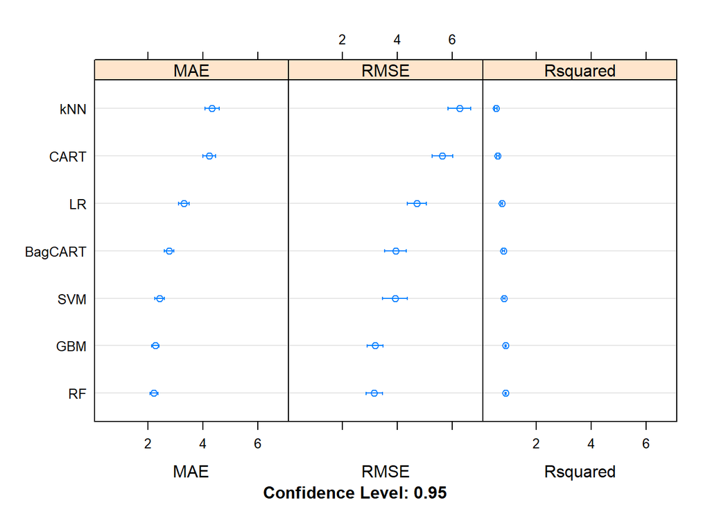

```r
dotplot(results)
```

```r
cat('The average RMSE from all models is:',
    mean(c(results$values$`LR~RMSE`,results$values$`CART~RMSE`,results$values$`kNN~RMSE`,results$values$`SVM~RMSE`,results$values$`BagCART~RMSE`,results$values$`RF~RMSE`,results$values$`GBM~RMSE`)))
```

```
## The average RMSE from all models is: 4.411917
```

## 5. Improve Accuracy or Results

After we achieve a short list of machine learning algorithms with good level of accuracy, we can leverage ways to improve the accuracy of the models.

Using the three best-perfoming algorithms from the previous section, we will Search for a combination of parameters for each algorithm that yields the best results.

### 5.a) Algorithm Tuning

Finally, we will tune the best-performing algorithms from each group further and see whether we can get more accuracy out of them.

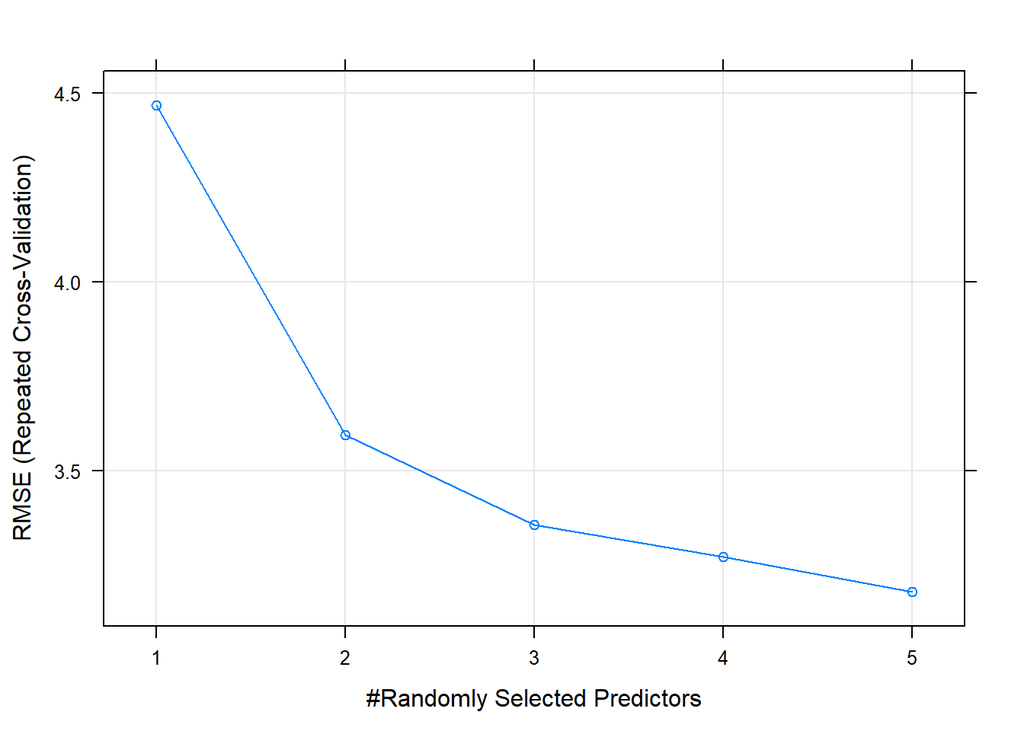

```r
# Tuning algorithm #1 - Random Forest
startTimeModule <- proc.time()
set.seed(seedNum)
grid <- expand.grid(mtry = c(1:5))
fit.final1 <- train(targetVar~., data=training, method="rf", metric=metricTarget, tuneGrid=grid, trControl=control)
plot(fit.final1)
```

```r
print(fit.final1)
```

```
## Random Forest
##
## 356 samples
##  13 predictor
##
## No pre-processing
## Resampling: Cross-Validated (10 fold, repeated 3 times)
## Summary of sample sizes: 320, 321, 322, 320, 320, 319, ...
## Resampling results across tuning parameters:
##
##   mtry  RMSE      Rsquared   MAE
##   1     4.467880  0.8035892  2.999671
##   2     3.594028  0.8597726  2.428388
##   3     3.355334  0.8726127  2.287656
##   4     3.272340  0.8757445  2.247870
##   5     3.177940  0.8816064  2.217681
##
## RMSE was used to select the optimal model using the smallest value.
## The final value used for the model was mtry = 5.
```

```r
proc.time()-startTimeModule
```

```
##    user  system elapsed
##   44.57    2.70   47.42
```

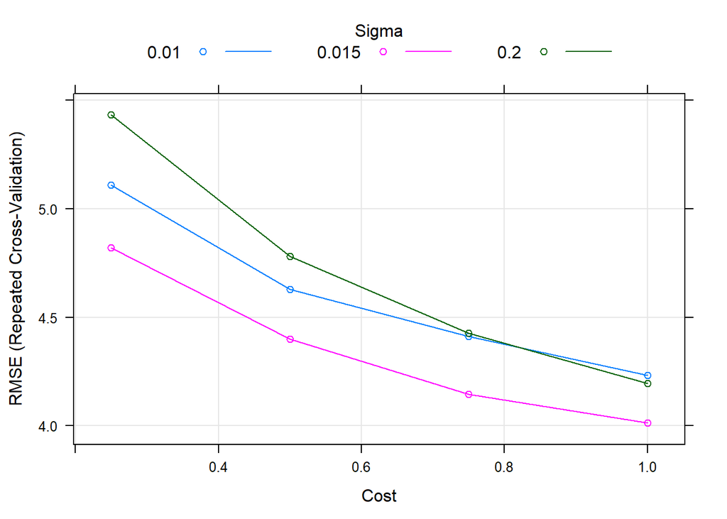

```r
# Tuning algorithm #2 - Support Vector Machine
startTimeModule <- proc.time()
set.seed(seedNum)
grid <- expand.grid(sigma = c(.01, .015, 0.2), C = c(0.25, 0.5, 0.75, 1))
fit.final2 <- train(targetVar~., data=training, method="svmRadial", metric=metricTarget, tuneGrid=grid, trControl=control)
plot(fit.final2)
```

```r
print(fit.final2)
```

```
## Support Vector Machines with Radial Basis Function Kernel
##
## 356 samples
##  13 predictor
##
## No pre-processing
## Resampling: Cross-Validated (10 fold, repeated 3 times)
## Summary of sample sizes: 320, 321, 322, 320, 320, 319, ...
## Resampling results across tuning parameters:
##
##   sigma  C     RMSE      Rsquared   MAE
##   0.010  0.25  5.107539  0.7230722  3.172492
##   0.010  0.50  4.629041  0.7578731  2.857125
##   0.010  0.75  4.411850  0.7764178  2.717694
##   0.010  1.00  4.233086  0.7911558  2.609617
##   0.015  0.25  4.818736  0.7476738  2.973204
##   0.015  0.50  4.399957  0.7809311  2.707589
##   0.015  0.75  4.145063  0.8013903  2.549742
##   0.015  1.00  4.012892  0.8119683  2.472852
##   0.200  0.25  5.431145  0.6950355  3.192584
##   0.200  0.50  4.780752  0.7488138  2.844618
##   0.200  0.75  4.427833  0.7776797  2.681061
##   0.200  1.00  4.196418  0.7957156  2.585268
##
## RMSE was used to select the optimal model using the smallest value.
## The final values used for the model were sigma = 0.015 and C = 1.
```

```r
proc.time()-startTimeModule
```

```
##    user  system elapsed
##    8.49    0.43    8.95
```

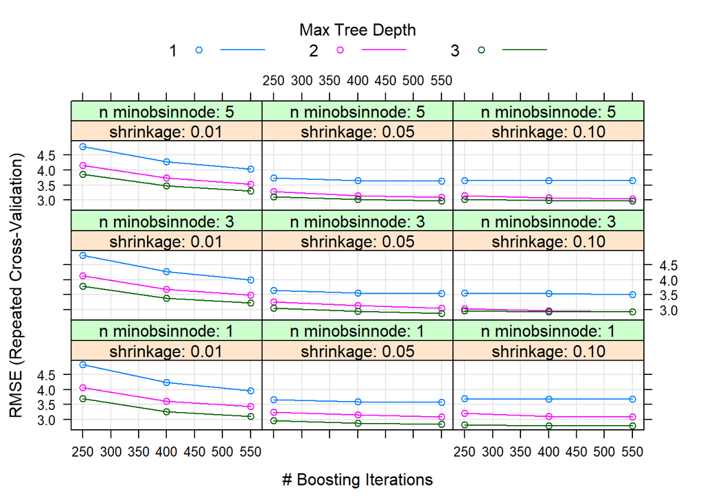

```r
# Tuning algorithm #3 - Stochastic Gradient Boosting
startTimeModule <- proc.time()
set.seed(seedNum)
grid <- expand.grid(.n.trees=c(250, 400, 550), .shrinkage=c(0.01, 0.05, 0.1), .interaction.depth=c(1, 2, 3), .n.minobsinnode=c(1, 3, 5))
fit.final3 <- train(targetVar~., data=training, method="gbm", metric=metricTarget, tuneGrid=grid, trControl=control, verbose=F)
plot(fit.final3)
```

```r
print(fit.final3)
```

```
## Stochastic Gradient Boosting
##
## 356 samples
##  13 predictor
##
## No pre-processing
## Resampling: Cross-Validated (10 fold, repeated 3 times)
## Summary of sample sizes: 320, 321, 322, 320, 320, 319, ...
## Resampling results across tuning parameters:
##
##   shrinkage  interaction.depth  n.minobsinnode  n.trees  RMSE
##   0.01       1                  1               250      4.826521
##   0.01       1                  1               400      4.236219
##   0.01       1                  1               550      3.955118
##   0.01       1                  3               250      4.810218
##   0.01       1                  3               400      4.272055
##   0.01       1                  3               550      3.992329
##   0.01       1                  5               250      4.774767
##   0.01       1                  5               400      4.272774
##   0.01       1                  5               550      4.034033
##   0.01       2                  1               250      4.071346
##   0.01       2                  1               400      3.616160
##   0.01       2                  1               550      3.444178
##   0.01       2                  3               250      4.138957
##   0.01       2                  3               400      3.676927
##   0.01       2                  3               550      3.496519
##   0.01       2                  5               250      4.147265
##   0.01       2                  5               400      3.728804
##   0.01       2                  5               550      3.534916
##   0.01       3                  1               250      3.703467
##   0.01       3                  1               400      3.268300
##   0.01       3                  1               550      3.113445
##   0.01       3                  3               250      3.794063
##   0.01       3                  3               400      3.380800
##   0.01       3                  3               550      3.222727
##   0.01       3                  5               250      3.859435
##   0.01       3                  5               400      3.470935
##   0.01       3                  5               550      3.294251
##   0.05       1                  1               250      3.664531
##   0.05       1                  1               400      3.586046
```

[output cut: 123 more lines]

```
##   0.8826474  2.208826
##   0.8856661  2.200451
##   0.8995883  2.102384
##   0.9016170  2.085108
##   0.9016695  2.084606
##   0.8922762  2.137053
##   0.8947654  2.122233
##   0.8951792  2.120927
##   0.8864258  2.157605
##   0.8889589  2.154112
##   0.8895887  2.152898
##
## RMSE was used to select the optimal model using the smallest value.
## The final values used for the model were n.trees = 400,
##  interaction.depth = 3, shrinkage = 0.1 and n.minobsinnode = 1.
```

```r
proc.time()-startTimeModule
```

```
##    user  system elapsed
##   60.06    0.02   60.13
```

### 5.d) Compare Algorithms After Tuning

```r
results <- resamples(list(RF=fit.final1, SVM=fit.final2, GBM=fit.final3))
summary(results)
```

```
##
## Call:
## summary.resamples(object = results)
##
## Models: RF, SVM, GBM
## Number of resamples: 30
##
## MAE
##         Min.  1st Qu.   Median     Mean  3rd Qu.     Max. NA's
## RF  1.539597 1.955272 2.152001 2.217681 2.494159 3.224504    0
## SVM 1.599383 2.109839 2.450425 2.472852 2.810188 3.454035    0
## GBM 1.359141 1.812593 2.079968 2.085108 2.344380 2.853660    0
##
## RMSE
##         Min.  1st Qu.   Median     Mean  3rd Qu.     Max. NA's
## RF  1.848055 2.560994 2.969388 3.177940 3.733497 5.063635    0
## SVM 2.060553 3.097084 3.929788 4.012892 4.869477 6.046544    0
## GBM 1.727001 2.361832 2.711783 2.792390 3.159640 4.076038    0
##
## Rsquared
##          Min.   1st Qu.    Median      Mean   3rd Qu.      Max. NA's
## RF  0.7302396 0.8562209 0.8911543 0.8816064 0.9211952 0.9524403    0
## SVM 0.6066466 0.7438352 0.8392417 0.8119683 0.8905584 0.9332124    0
## GBM 0.8141483 0.8671444 0.9064710 0.9016170 0.9397495 0.9646256    0
```

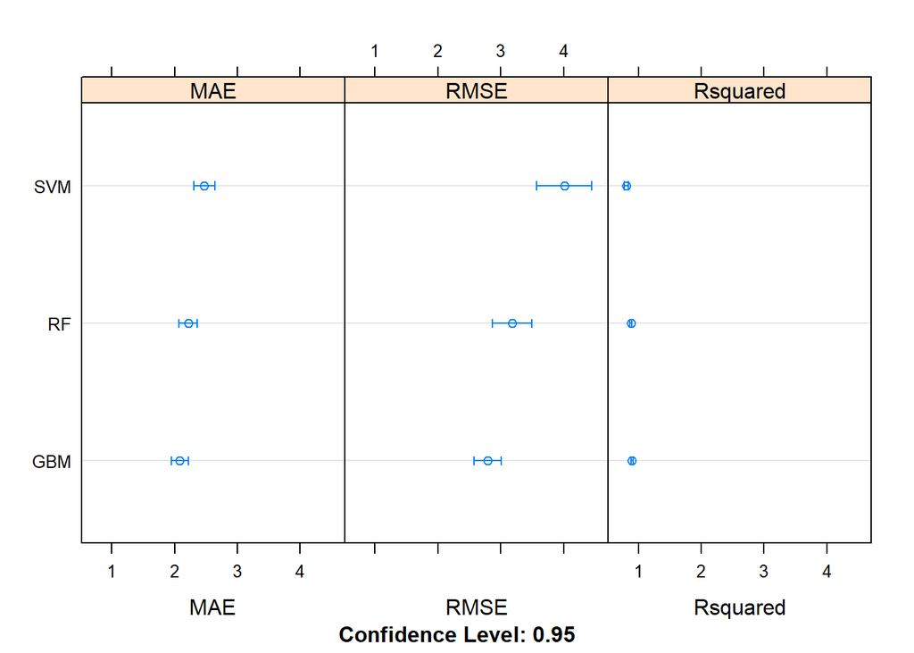

```r
dotplot(results)
```

## 6. Finalize Model and Present Results

Once we have narrow down to a model that we believe can make accurate predictions on unseen data, we are ready to finalize it. Finalizing a model may involve sub-tasks such as:

- Using an optimal model tuned to make predictions on unseen data.
- Creating a standalone model using the tuned parameters
- Saving an optimal model to file for later use.

### 6.a) Predictions on validation dataset

```r
predictions <- predict(fit.final3, newdata=validation)
valY <- validation[,totCol]
print(RMSE(predictions, valY))
```

```
## [1] 3.591217
```

```r
print(R2(predictions, valY))
```

```
## [1] 0.8628615
```

### 6.b) Create standalone model on entire training dataset

```r
startTimeModule <- proc.time()
library(gbm)
set.seed(seedNum)
#grid <- expand.grid(.n.trees=400, .interaction.depth=3, .shrinkage=0.1, .n.minobsinnode=1)
#finalModel <- train(targetVar~., data=entireDataset, method="gbm", metric=metricTarget, tuneGrid=grid, trControl=control, verbose=F)
finalModel <- gbm(targetVar~., data=entireDataset, n.trees=400, shrinkage=0.1, interaction.depth=3, n.minobsinnode=1)
```

```
## Distribution not specified, assuming gaussian ...
```

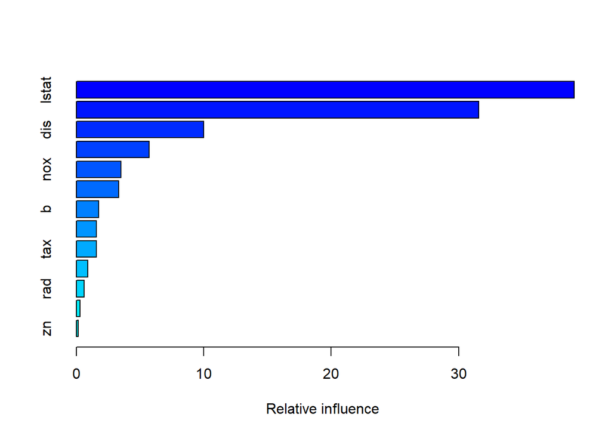

```
##             var    rel.inf
## lstat     lstat 39.0685353
## rm           rm 31.5692439
## dis         dis  9.9781722
## crim       crim  5.7149723
## nox         nox  3.5040398
## ptratio ptratio  3.3358447
## b             b  1.7579485
## age         age  1.5718526
## tax         tax  1.5595239
## indus     indus  0.9021083
## rad         rad  0.5939085
## chas       chas  0.2821474
## zn           zn  0.1617026
```

```r
summary(finalModel)
```

```r
proc.time()-startTimeModule
```

```
##    user  system elapsed
##    0.18    0.01    0.20
```

### 6.c) Save model for later use

```r
#saveRDS(finalModel, "./finalModel_Regression.rds")
```

```r
proc.time()-startTimeScript
```

```
##    user  system elapsed
##  195.23    6.97  204.37
```